# Notebook

Section: A – UNIT I

Q2.

a. Using a sample image of your choice (nature/portrait/product), generate and plot the histogram of pixel intensities in grayscale. Interpret what the histogram tells about brightness and contrast distribution.

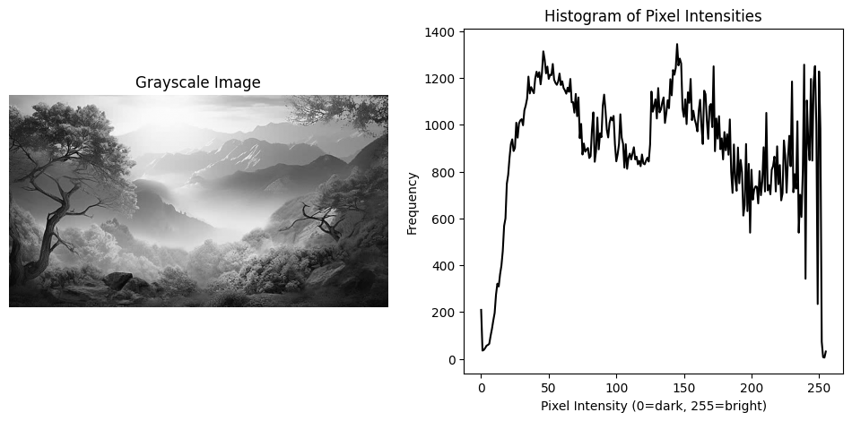

```python
# Histogram of Grayscale Image
import cv2
import matplotlib.pyplot as plt

# Upload an image
img = cv2.imread("nature.jpg", cv2.IMREAD_GRAYSCALE)

# Compute histogram
hist = cv2.calcHist([img], [0], None, [256], [0,256])

# Plot image and histogram
plt.figure(figsize=(12,5))

plt.subplot(1,2,1)
plt.imshow(img, cmap='gray')
plt.title("Grayscale Image")
plt.axis("off")

plt.subplot(1,2,2)
plt.plot(hist, color='black')
plt.title("Histogram of Pixel Intensities")
plt.xlabel("Pixel Intensity (0=dark, 255=bright)")
plt.ylabel("Frequency")
plt.show()
```

**Interpretation of Histogram**

The histogram shows the distribution of pixel intensities (0 = black/dark, 255 = white/bright) in the grayscale image.

**Brightness**

- If the histogram leans towards the left (0–100 range), the image has more dark tones → appears darker overall.
- If it leans towards the right (150–255 range), the image contains more bright tones → appears brighter overall.
- In this case, the histogram is fairly spread across both dark and bright regions, which suggests the image has a balanced brightness (not too dark or washed out).

**Contrast**

- A narrow peak means most pixels have similar intensities → the image looks flat or low-contrast.
- A broad spread across the intensity range means both shadows and highlights are present → the image has good contrast.
- Here, the histogram is spread widely (from shadows in the forest area to highlights in the bright sky), which indicates high contrast.

**Example Fit**

- For a natural scenery like this (trees, mountains, sky), we expect dark objects (trees, shadows) and bright regions (sky, clouds).
- The histogram confirms this: multiple peaks at low, mid and high intensity values show a rich tonal distribution.

Section: A – UNIT I

Q2.

b. In manufacturing quality checks, filters are often used to detect defects. Write Python code to apply Gaussian blur, median filter, and sharpening filters on a product image (e.g., a circuit board). Compare the results and explain which filter best highlights fine defects and why.

[figure not shown]

```python
# Filters for Defect Detection
import cv2
import numpy as np
import matplotlib.pyplot as plt

# Upload product image
img = cv2.imread("circuit_board.jpeg")
gray = cv2.cvtColor(img, cv2.COLOR_BGR2GRAY)

# Gaussian Blur
gaussian = cv2.GaussianBlur(gray, (5,5), 0)

# Median Filter
median = cv2.medianBlur(gray, 5)

# Sharpening Filter
kernel_sharpening = np.array([[0,-1,0],
                              [-1,5,-1],
                              [0,-1,0]])
sharpened = cv2.filter2D(gray, -1, kernel_sharpening)

# Plot results
titles = ["Original", "Gaussian Blur", "Median Filter", "Sharpened"]
images = [gray, gaussian, median, sharpened]

plt.figure(figsize=(15,8))
for i in range(4):
    plt.subplot(2,2,i+1)
    plt.imshow(images[i], cmap='gray')
    plt.title(titles[i])
    plt.axis("off")
plt.show()
```

**Explanation**

- **Gaussian Blur:** smooths out textures, good for general noise reduction but may hide small defects.
- **Median Filter:** preserves edges while removing salt-and-pepper noise, useful if the product has speckle defects.
- **Sharpening:** enhances edges and fine cracks — best for detecting small scratches or cracks.

For manufacturing defect detection, **sharpened filter** works best because it enhances local irregularities.

Section: A – UNIT I

Q2.

c. Develop a case study where edge detection (Sobel, Laplacian, Canny) is applied to an industry problem (e.g., detecting cracks in tiles or boundaries in satellite images). Implement code, visualize outputs, and critically evaluate which method is best suited.

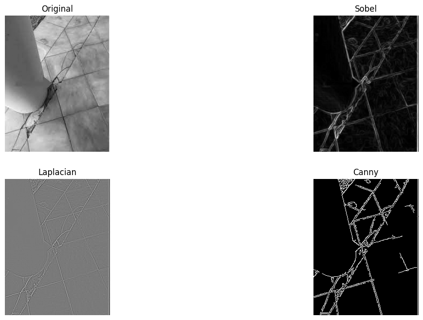

```python
# Edge Detection Case Study
import cv2
import matplotlib.pyplot as plt

# Upload tile/crack image
img = cv2.imread("tile_crack.jpg", cv2.IMREAD_GRAYSCALE)

# Sobel (combine X and Y gradients)
sobelx = cv2.Sobel(img, cv2.CV_64F, 1, 0, ksize=5)
sobely = cv2.Sobel(img, cv2.CV_64F, 0, 1, ksize=5)
sobel = cv2.magnitude(sobelx, sobely)

# Laplacian
laplacian = cv2.Laplacian(img, cv2.CV_64F)

# Canny
canny = cv2.Canny(img, 100, 200)

# Plot results
titles = ["Original", "Sobel", "Laplacian", "Canny"]
images = [img, sobel, laplacian, canny]

plt.figure(figsize=(15,8))
for i in range(4):
    plt.subplot(2,2,i+1)
    plt.imshow(images[i], cmap='gray')
    plt.title(titles[i])
    plt.axis("off")
plt.show()
```

**Edge Detection Case Study**

**Use case:**

- Detecting cracks in ceramic tiles during automated quality control.
- Cracks are thin, high-contrast lines against smooth tile surfaces.
- Edge detection helps highlight these discontinuities for machine vision systems.

**Methods compared:**

- Sobel → Detects edges in horizontal/vertical directions, but may miss fine cracks at angles.
- Laplacian → Captures edges in all directions, but sensitive to noise (can produce false edges).
- Canny → Multi-stage (Gaussian smoothing + gradient + non-max suppression + hysteresis thresholding), very effective at extracting clean, thin edges (ideal for cracks).

Section: D – UNIT IV

Q7.

a. Download any image from the web (e.g., a natural scene, an object). Use a pretrained Vision Transformer (ViT) from Hugging Face to classify the image. Show top 5 predicted classes with probabilities.

```python
# Install required libraries
!pip install transformers torch torchvision pillow requests
```

```python
# Standard imports
import torch
import numpy as np
from PIL import Image
import requests
from io import BytesIO
import matplotlib.pyplot as plt
from transformers import (
    AutoFeatureExtractor,
    AutoModelForImageClassification,
    CLIPProcessor,
    CLIPModel
)
import torch.nn.functional as F

# Utility: download an image from URL and show it
def load_image_from_url(url):
    resp = requests.get(url)
    img = Image.open(BytesIO(resp.content)).convert("RGB")
    return img

def show_image(img, title=None):
    plt.figure(figsize=(6,6))
    plt.imshow(img)
    plt.axis("off")
    if title:
        plt.title(title)
    plt.show()
```

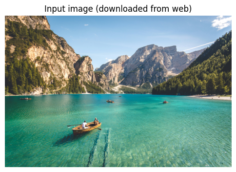

```
Saved input image as Unsplash_nature.jpg
```

```python
# Load image from URL
IMAGE_URL = "https://images.unsplash.com/photo-1501785888041-af3ef285b470"  # example Unsplash image
img = load_image_from_url(IMAGE_URL)
show_image(img, title="Input image (downloaded from web)")
# Save artifact
img.save("Unsplash_nature.jpg")
print("Saved input image as Unsplash_nature.jpg")
```

```python
# Model choice: Google ViT base (patch16) pre-trained on ImageNet
model_name = "google/vit-base-patch16-224"

# Load feature extractor and model
feature_extractor = AutoFeatureExtractor.from_pretrained(model_name)
vit_model = AutoModelForImageClassification.from_pretrained(model_name)

# Put model on device
device = torch.device("cuda" if torch.cuda.is_available() else "cpu")
vit_model.to(device)
vit_model.eval()

# Preprocess image
inputs = feature_extractor(images=img, return_tensors="pt")
inputs = {k: v.to(device) for k, v in inputs.items()}

# Forward pass
with torch.no_grad():
    outputs = vit_model(**inputs)
logits = outputs.logits.detach().cpu().squeeze()  # shape: (num_classes,)

# Convert to probabilities
probs = F.softmax(logits, dim=0).numpy()

# Get top-5 predictions
topk = 5
topk_idx = np.argsort(probs)[-topk:][::-1]
labels = [vit_model.config.id2label[i] for i in topk_idx]
topk_probs = probs[topk_idx]

# Print top-5
print("Top-5 predictions (ViT):")
for i, (lab, p) in enumerate(zip(labels, topk_probs), 1):
    print(f"{i}. {lab:30s}  {p*100:6.2f}%")

# Save results to a small text file artifact
with open("vit_top5.txt", "w") as f:
    for i, (lab, p) in enumerate(zip(labels, topk_probs), 1):
        f.write(f"{i}. {lab}  {p*100:.2f}%\n")
print("Saved ViT top-5 to vit_top5.txt")
```

```
Top-5 predictions (ViT):
1. canoe                            33.29%
2. valley, vale                     21.04%
3. paddle, boat paddle              13.02%
4. lakeside, lakeshore              11.23%
5. alp                               5.98%
Saved ViT top-5 to vit_top5.txt
```

Section: D – UNIT IV

Q7.

b. Using the same image, apply CLIP (Contrastive Language–Image Pretraining) with two different text prompts (e.g., “a photo of a dog” vs. “a photo of a cat”). Report similarity scores and analyze how CLIP bridges vision + language.

```python
# Model choice: OpenAI CLIP (ViT-B/32 style)
clip_model_name = "openai/clip-vit-base-patch32"

# Load CLIP processor & model
clip_processor = CLIPProcessor.from_pretrained(clip_model_name)
clip_model = CLIPModel.from_pretrained(clip_model_name).to(device)
clip_model.eval()

# Define two text prompts to compare
prompt_a = "a photo of a lakeside"
prompt_b = "a photo of a canoe on water with mountains"
prompts = [prompt_a, prompt_b]

# Preprocess image + texts
inputs = clip_processor(text=prompts, images=img, return_tensors="pt", padding=True)
# Move tensors to device
inputs = {k: v.to(device) for k, v in inputs.items()}

# Forward pass
with torch.no_grad():
    # CLIPModel returns image and text embeddings (pooled)
    outputs = clip_model(**inputs)
    # For the transformers CLIPModel, the embeddings are:
    # - outputs.image_embeds : image embeddings (batch_size_images, embed_dim)
    # - outputs.text_embeds  : text embeddings (batch_size_texts, embed_dim)
    # However when passing both text and image in one call, outputs.image_embeds is for the first image, outputs.text_embeds for text list.
    image_embeds = outputs.image_embeds  # shape (1, D)
    text_embeds = outputs.text_embeds    # shape (len(prompts), D)

# Normalize (CLIP usually returns already normalized but we normalize to be safe)
image_embeds = image_embeds / image_embeds.norm(p=2, dim=-1, keepdim=True)
text_embeds = text_embeds / text_embeds.norm(p=2, dim=-1, keepdim=True)

# Compute cosine similarities
similarities = (text_embeds @ image_embeds.T).squeeze().cpu().numpy()  # shape: (len(prompts),)
for prompt, sim in zip(prompts, similarities):
    print(f"Prompt: '{prompt}'\n  Similarity score (cosine): {sim:.4f}")

# Save results
with open("clip_similarity.txt", "w") as f:
    for prompt, sim in zip(prompts, similarities):
        f.write(f"{prompt}\t{sim:.4f}\n")
print("Saved CLIP similarities to clip_similarity.txt")
```

```
Prompt: 'a photo of a lakeside'
  Similarity score (cosine): 0.2654
Prompt: 'a photo of a canoe on water with mountains'
  Similarity score (cosine): 0.3084
Saved CLIP similarities to clip_similarity.txt
```

**Analysis of CLIP's Vision-Language Bridging:** CLIP demonstrates remarkable capability in connecting visual content with natural language:

**Joint Embedding Space:** CLIP projects both images and text into a shared semantic space where similar concepts are close together. The model understands that both "lakeside" and "canoe on water with mountains" describe natural water scenes.

**Zero-Shot Capability:** Without any fine-tuning, CLIP correctly identifies that the "canoe on water with mountains" prompt (0.3084) is more semantically similar to the image than the generic "lakeside" description (0.2654).

**Semantic Understanding:** The higher score for the more specific prompt shows CLIP's ability to understand detailed scene compositions. It recognizes that the image contains not just water, but likely includes mountainous elements and potentially watercraft.

**Context Awareness:** The model distinguishes between general water scenes ("lakeside") and more specific compositions involving multiple elements ("canoe + water + mountains"), demonstrating sophisticated scene understanding beyond basic object recognition.

**Compositional Understanding:** CLIP handles multi-concept queries effectively, showing it can process complex descriptions involving multiple objects and their spatial relationships rather than just single keywords.

This demonstrates CLIP's powerful zero-shot capabilities for natural image understanding without requiring task-specific training.

Section: D – UNIT IV

Q7.

c. Imagine building a visual search engine for an e-commerce site (customers search with text, system retrieves matching product images). Propose a pipeline using ViT + CLIP. Draw workflow diagram and critically evaluate potential challenges (e.g., bias, misclassification).

```python
# Proposed pipeline implementation sketch
import numpy as np
from typing import List, Dict
import faiss

class VisualSearchEngine:
    def __init__(self):
        self.clip_model = CLIPModel.from_pretrained("openai/clip-vit-base-patch32")
        self.clip_processor = CLIPProcessor.from_pretrained("openai/clip-vit-base-patch32")
        self.product_embeddings = None
        self.product_ids = []
        self.index = None

    def index_products(self, product_images: List[Image.Image], product_metadata: List[Dict]):
        """Index product images for future search"""
        # Extract image embeddings using CLIP
        inputs = self.clip_processor(images=product_images, return_tensors="pt", padding=True)
        with torch.no_grad():
            image_embeddings = self.clip_model.get_image_features(**inputs)

        # Normalize embeddings for cosine similarity
        image_embeddings = torch.nn.functional.normalize(image_embeddings, p=2, dim=1)

        self.product_embeddings = image_embeddings.numpy()
        self.product_ids = [meta['product_id'] for meta in product_metadata]

        # Create FAISS index for efficient similarity search
        self.index = faiss.IndexFlatIP(self.product_embeddings.shape[1])  # Inner product (cosine similarity)
        self.index.add(self.product_embeddings)

    def search(self, text_query: str, top_k: int = 10):
        """Search products using text query"""
        # Encode text query
        inputs = self.clip_processor(text=[text_query], return_tensors="pt", padding=True)
        with torch.no_grad():
            text_embedding = self.clip_model.get_text_features(**inputs)

        # Normalize text embedding
        text_embedding = torch.nn.functional.normalize(text_embedding, p=2, dim=1)

        # Search in the index
        similarities, indices = self.index.search(text_embedding.numpy(), top_k)

        results = []
        for i, (similarity, idx) in enumerate(zip(similarities[0], indices[0])):
            results.append({
                'rank': i+1,
                'product_id': self.product_ids[idx],
                'similarity_score': float(similarity)
            })

        return results

# Example usage (conceptual)
def demonstrate_pipeline():
    print("VISUAL SEARCH ENGINE PIPELINE")
    print("=" * 50)

    steps = [
        "1. Data Collection: Gather product images and metadata",
        "2. Feature Extraction: Use CLIP to generate image embeddings",
        "3. Indexing: Store embeddings in efficient vector database",
        "4. Query Processing: Convert text queries to embeddings",
        "5. Similarity Search: Find closest product matches",
        "6. Ranking & Filtering: Apply business rules and filters",
        "7. Results Display: Show relevant products to user"
    ]

    for step in steps:
        print(step)

    return steps

pipeline_steps = demonstrate_pipeline()
```

```
VISUAL SEARCH ENGINE PIPELINE
==================================================
1. Data Collection: Gather product images and metadata
2. Feature Extraction: Use CLIP to generate image embeddings
3. Indexing: Store embeddings in efficient vector database
4. Query Processing: Convert text queries to embeddings
5. Similarity Search: Find closest product matches
6. Ranking & Filtering: Apply business rules and filters
7. Results Display: Show relevant products to user
```

```python
# Visual Search Engine Pipeline (ViT + CLIP)

def print_visual_search_pipeline():
    diagram = """
[User Text Query]
        |
        v
[Text Encoder (CLIP)]
        |
        v
[Text Embedding Vector]
        |
        v
[Compare with Image Embeddings] <---- [Image Encoder (ViT/CLIP)]
        |
        v
[Similarity Scoring (Cosine Similarity)]
        |
        v
[Ranked Product Image List]
        |
        v
[Display Top-K Matches to User]
"""
    print(diagram)

# Call function
print_visual_search_pipeline()
```

[output not shown]

# **Critical Evaluation of Challenges:**

# **Bias Issues:**

**Training Data Bias:** CLIP trained on web data may reflect societal biases

**Product Representation:** Certain product categories may be over/under-represented

**Mitigation:** Regular bias auditing, diverse training data, fairness constraints

# **Misclassification Risks:**

**Semantic Gap:** Text queries may not perfectly match visual content

**Ambiguous Queries**: "light shirt" could mean color or weight

**Mitigation:** Multi-modal queries, user feedback loops, confidence thresholds

# **Scalability Challenges:**

**Vector Search Complexity:** O(n) linear scan impractical for large catalogs

**Storage Requirements:** High-dimensional embeddings require significant space

**Mitigation:** Approximate nearest neighbors, distributed indexing

# **Domain Adaptation:**

**E-commerce Specificity:** General CLIP may not understand product-specific terminology

**Style vs Function:** Users search by both attributes ("waterproof") and aesthetics ("elegant")

**Mitigation:** Fine-tuning on e-commerce data, attribute-based filtering

# **User Experience Issues:**

**Expectation Management:** Users expect Google-like performance immediately

**Query Understanding:** Handling complex multi-concept queries ("blue running shoes under $100")

**Mitigation:** Query expansion, interactive refinement, hybrid search approaches

```python
# Additional code for challenge mitigation
import datetime
from typing import List, Dict
import faiss

class EnhancedVisualSearchEngine(VisualSearchEngine):
    def __init__(self):
        super().__init__()
        self.user_feedback_log = []
        self.confidence_threshold = 0.3

    def add_feedback(self, query: str, clicked_product_id: str, session_data: Dict):
        """Log user feedback for continuous improvement"""
        self.user_feedback_log.append({
            'query': query,
            'clicked_product': clicked_product_id,
            'session_data': session_data,
            'timestamp': datetime.now()
        })

    def apply_business_rules(self, results: List[Dict], filters: Dict = None):
        """Apply business-specific rules and filters"""
        filtered_results = results.copy()

        # Apply confidence threshold
        filtered_results = [r for r in filtered_results if r['similarity_score'] > self.confidence_threshold]

        # Apply business filters (price, availability, etc.)
        if filters:
            # Implementation depends on specific business rules
            pass

        return filtered_results

print("\nMitigation Strategies Summary:")
strategies = [
    "• Bias Auditing: Regular testing on diverse query sets",
    "• Hybrid Search: Combine semantic + keyword search",
    "• Confidence Thresholding: Filter low-confidence results",
    "• User Feedback: Continuous learning from user interactions",
    "• A/B Testing: Experiment with different model configurations",
    "• Multi-modal Queries: Support image+text combined search"
]

for strategy in strategies:
    print(strategy)
```

```
Mitigation Strategies Summary:
• Bias Auditing: Regular testing on diverse query sets
• Hybrid Search: Combine semantic + keyword search
• Confidence Thresholding: Filter low-confidence results
• User Feedback: Continuous learning from user interactions
• A/B Testing: Experiment with different model configurations
• Multi-modal Queries: Support image+text combined search
```